# RLT Package Testing Regression Functions and Features

Ruoqing Zhu

Last Updated: August 25, 2023

## Install and Load Package

Install and load the GitHub version of the RLT package. Do not use the CRAN version.

```r
  # install.packages("devtools")
  # devtools::install_github("teazrq/RLT")
  library(RLT)
## RLT and random forests v4.2.5
## pre-release at github.com/teazrq/RLT
```

Load other packages used in this guide.

```r
  library(randomForest)
  library(randomForestSRC)
  library(ranger)
```

## Benchmark Against Existing Packages

```r
  library(parallel)
  # Set seed for reproducibility
  set.seed(1)

  # Define data size
  trainn <- 800
  testn <- 1000
  n <- trainn + testn
  p <- 30

  # Generate continuous variables (X1) and categorical variables (X2)
  X1 <- matrix(rnorm(n * p / 2), n, p / 2)
  X2 <- matrix(as.integer(runif(n * p / 2) * 3), n, p / 2)

  # Combine continuous and categorical variables into a data frame (X)
  X <- data.frame(X1, X2)

  # Convert the second half of the columns in X to factors
  X[, (p / 2 + 1):p] <- lapply(X[, (p / 2 + 1):p], as.factor)

  # Generate outcomes (y)
  y <- 1 + rowSums(X[, 2:6]) + 2 * (X[, p / 2 + 1] %in% c(1, 3)) + rnorm(n)

  # Set tuning parameters
  ntrees <- 1000
  ncores <- detectCores() - 1
  nmin <- 30
  mtry <- p / 2
  samplereplace <- TRUE
  sampleprob <- 0.80
  rule <- "best"
  nsplit <- ifelse(rule == "best", 0, 3)
  importance <- TRUE

  # Split data into training and testing sets
  trainX <- X[1:trainn, ]
  trainY <- y[1:trainn]
  testX <- X[(trainn + 1):(trainn + testn), ]
  testY <- y[(trainn + 1):(trainn + testn)]
```

```r
  # recording results
  metric = data.frame(matrix(NA, 4, 6))
  rownames(metric) = c("RLT", "randomForestSRC", "randomForest", "ranger")
  colnames(metric) = c("fit.time", "pred.time", "oob.error", "pred.error",
                       "obj.size", "tree.size")

  # using RLT package
  start_time <- Sys.time()
  RLTfit <- RLT(trainX, trainY, model = "regression",
                ntrees = ntrees, mtry = mtry, nmin = nmin,
                resample.prob = sampleprob, split.gen = rule,
                resample.replace = samplereplace,
                nsplit = nsplit, importance = importance,
                param.control = list("alpha" = 0),
                ncores = ncores, verbose = TRUE)
## Regression Random Forest ...
## ---------- Parameters Summary ----------
##               (N, P) = (800, 30)
##           # of trees = 1000
##         (mtry, nmin) = (15, 30)
##       split generate = Best
##             sampling = 0.8 w/ replace
##   (Obs, Var) weights = (No, No)
##           importance = permute
##        reinforcement = No
## ----------------------------------------
  metric[1, 1] = difftime(Sys.time(), start_time, units = "secs")
  start_time <- Sys.time()
  RLTPred <- predict(RLTfit, testX, ncores = ncores)
  metric[1, 2] = difftime(Sys.time(), start_time, units = "secs")
  metric[1, 3] = mean((RLTfit$Prediction - trainY)^2)
  metric[1, 4] = mean((RLTPred$Prediction - testY)^2)
  metric[1, 5] = object.size(RLTfit)
  metric[1, 6] = mean(unlist(lapply(RLTfit$FittedForest$SplitVar, length)))

  # use randomForestSRC
  options(rf.cores = ncores)
  start_time <- Sys.time()
  rsffit <- rfsrc(y ~ ., data = data.frame(trainX, "y"= trainY),
                  ntree = ntrees, nodesize = nmin/2, mtry = mtry,
                  samptype = ifelse(samplereplace == TRUE, "swor", "swr"),
                  nsplit = nsplit, sampsize = trainn*sampleprob,
                  importance = ifelse(importance, "permute", "none"))
  metric[2, 1] = difftime(Sys.time(), start_time, units = "secs")
  start_time <- Sys.time()
  rsfpred = predict(rsffit, data.frame(testX))
  metric[2, 2] = difftime(Sys.time(), start_time, units = "secs")
  metric[2, 3] = mean((rsffit$predicted.oob - trainY)^2)
  metric[2, 4] = mean((rsfpred$predicted - testY)^2)
  metric[2, 5] = object.size(rsffit)
  metric[2, 6] = rsffit$forest$totalNodeCount / rsffit$ntree

  # use randomForest
  start_time <- Sys.time()
  rf.fit <- randomForest(trainX, trainY, ntree = ntrees,
                         mtry = mtry, nodesize = nmin,
                         replace = samplereplace,
                         sampsize = trainn*sampleprob,
                         importance = importance)
  metric[3, 1] = difftime(Sys.time(), start_time, units = "secs")
  start_time <- Sys.time()
  rf.pred <- predict(rf.fit, testX)
  metric[3, 2] = difftime(Sys.time(), start_time, units = "secs")
  metric[3, 3] = mean((rf.fit$predicted - trainY)^2)
  metric[3, 4] = mean((rf.pred - testY)^2)
  metric[3, 5] = object.size(rf.fit)
  metric[3, 6] = mean(colSums(rf.fit$forest$nodestatus != 0))


  # use ranger
  start_time <- Sys.time()
  rangerfit <- ranger(trainY ~ ., data = data.frame(trainX),
                      num.trees = ntrees, min.node.size = nmin,
                      mtry = mtry, num.threads = ncores,
                      replace = samplereplace,
                      sample.fraction = sampleprob,
                      importance = "permutation",
                      respect.unordered.factors = "partition")
  metric[4, 1] = difftime(Sys.time(), start_time, units = "secs")
  start_time <- Sys.time()
  rangerpred = predict(rangerfit, data.frame(testX))
  metric[4, 2] = difftime(Sys.time(), start_time, units = "secs")
  metric[4, 3] = mean((rangerfit$predictions - trainY)^2)
  metric[4, 4] = mean((rangerpred$predictions - testY)^2)
  metric[4, 5] = object.size(rangerfit)
  metric[4, 6] = mean(unlist(lapply(rangerfit$forest$split.varIDs, length)))

  # performance summary
  metric
```

|  | fit.time | pred.time | oob.error | pred.error | obj.size | tree.size |
| --- | --- | --- | --- | --- | --- | --- |
| RLT | 0.1768870 | 0.01905489 | 2.326833 | 2.348519 | 4855800 | 79.080 |
| randomForestSRC | 0.4973919 | 0.06005192 | 2.329721 | 2.417986 | 9881600 | 81.296 |
| randomForest | 2.5172732 | 0.04084015 | 2.327304 | 2.372427 | 3212440 | 79.312 |
| ranger | 0.2504189 | 0.02087283 | 2.318683 | 2.358706 | 2842528 | 79.352 |

## Variable Importance

We first plot the variable importance from the permutation version. This usually requires a significant number of out-of-bag samples.

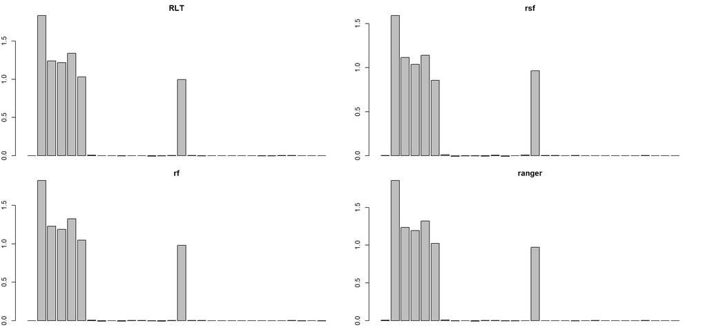

```r
  par(mfrow=c(2,2))
  par(mar = c(1, 2, 2, 2))

  barplot(as.vector(RLTfit$VarImp), main = "RLT")
  barplot(as.vector(rsffit$importance), main = "rsf")
  barplot(rf.fit$importance[, 1], main = "rf")
  barplot(as.vector(rangerfit$variable.importance), main = "ranger")
```

We also calculate the variable importance from the distributed child node assignment approach. In this case, we calculate all possible terminal nodes and their probabilities for a subject that ever land in that terminal node. This is to send it down to both two child nodes with weights proportional to the child node sizes. In this case, we can calculate the variable importance for sampling without replacement with just one out-of-bag sample.

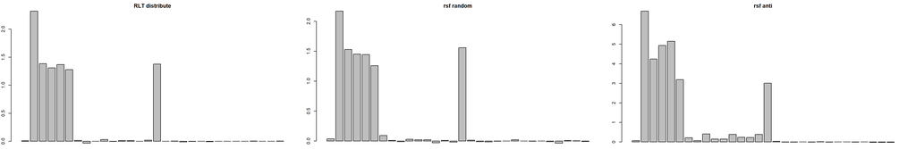

```r
  # using RLT package
  RLTfit <- RLT(trainX, trainY, model = "regression",
                ntrees = ntrees, mtry = mtry, nmin = nmin,
                split.gen = rule, nsplit = nsplit,
                resample.prob = (trainn - 1)/trainn,
                resample.replace = FALSE,
                importance = "distribute",
                ncores = ncores,
                verbose = TRUE,
                param.control = list("resample.track" = TRUE))
## Regression Random Forest ...
## ---------- Parameters Summary ----------
##               (N, P) = (800, 30)
##           # of trees = 1000
##         (mtry, nmin) = (15, 30)
##       split generate = Best
##             sampling = 0.99875 w/o replace
##   (Obs, Var) weights = (No, No)
##           importance = distribute
##        reinforcement = No
## ----------------------------------------

  # use randomForestSRC
  rsffit <- rfsrc(y ~ ., data = data.frame(trainX, "y"= trainY),
                  ntree = ntrees, nodesize = nmin/2, mtry = mtry,
                  samptype = "swor", nsplit = nsplit,
                  sampsize = trainn - 1,
                  importance = "random")

  rsffit2 <- rfsrc(y ~ ., data = data.frame(trainX, "y"= trainY),
                  ntree = ntrees, nodesize = nmin/2, mtry = mtry,
                  samptype = "swor", nsplit = nsplit,
                  sampsize = trainn - 1,
                  importance = "anti")
  par(mfrow=c(1,3))
  par(mar = c(1, 2, 2, 2))

  barplot(as.vector(RLTfit$VarImp), main = "RLT distribute")
  barplot(as.vector(rsffit$importance), main = "rsf random")
  barplot(as.vector(rsffit2$importance), main = "rsf anti")
```

## Print a Single Tree

You can use the `get.one.tree()` function to peek into a single tree.

```r
  get.one.tree(RLTfit, 1)
## Tree #1 in the fitted regression forest:
```

| SplitVar | SplitValue | LeftNode | RightNode | NodeWeight | NodeAve |
| --- | --- | --- | --- | --- | --- |
| X3 | -0.07367435 | 2 | 3 | 799 | 0.0000000 |
| X4 | 0.32948211 | 4 | 5 | 382 | 0.0000000 |
| X6 | -0.14874108 | 50 | 51 | 417 | 0.0000000 |
| X2 | 0.57412460 | 6 | 7 | 246 | 0.0000000 |
| X5 | 0.89288947 | 36 | 37 | 136 | 0.0000000 |
| X5 | 0.51620252 | 8 | 9 | 180 | 0.0000000 |
| X4 | -2.71350546 | 28 | 29 | 66 | 0.0000000 |
| X6 | 0.02947737 | 10 | 11 | 134 | 0.0000000 |
| X1.1 (F) | 4.00000000 | 26 | 27 | 46 | 0.0000000 |
| X1.1 (F) | 4.00000000 | 12 | 13 | 76 | 0.0000000 |

[output cut: 83 more lines]

## Random Forest Kernel

Let’s generate a new dataset with 5 continuous variables. The true model depends on just the first two variables.

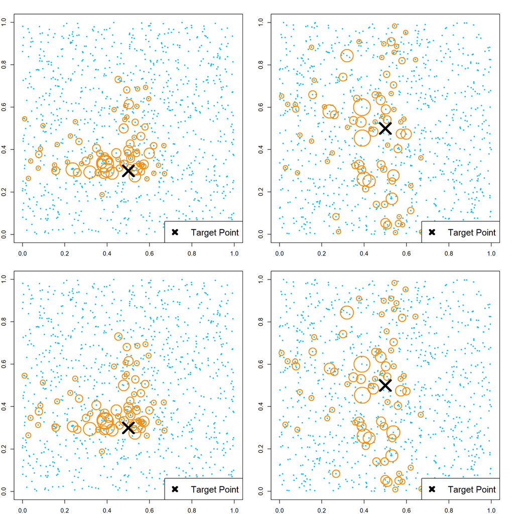

```r
  # generate data
  n = 1000; p = 5
  X = matrix(runif(n*p), n, p)
  y = X[, 1] + X[, 2] + rnorm(n)

  # fit model
  RLTfit <- RLT(X, y, model = "regression",
                ntrees = 50, nmin = 4, mtry = 5,
                split.gen = "best", resample.prob = 0.8,
                resample.replace = FALSE,
                importance = TRUE, param.control = list("resample.track" = TRUE))

  par(mfrow=c(2, 2))

  # target point
  newX = matrix(c(0.5, 0.3, 0.5, 0.5, 0.5),
                1, 5)

  # get kernel weights defined by the kernel function
  KernelW = forest.kernel(RLTfit, X1 = newX, X2 = X)$Kernel

  par(mar = c(2, 2, 2, 2))
  plot(X[, 1], X[, 2], col = "deepskyblue", pch = 19, cex = 0.5)
  points(X[, 1], X[, 2], col = "darkorange", cex = 10*sqrt(KernelW/sqrt(sum(KernelW^2))), lwd = 2)
  points(newX[1], newX[2], col = "black", pch = 4, cex = 4, lwd = 5)
  legend("bottomright", "Target Point", pch = 4, col = "black",
         lwd = 5, lty = NA, cex = 1.5)

  # check against X3
  plot(X[, 1], X[, 3], col = "deepskyblue", pch = 19, cex = 0.5)
  points(X[, 1], X[, 3], col = "darkorange", cex = 10*sqrt(KernelW/sqrt(sum(KernelW^2))), lwd = 2)
  points(newX[1], newX[3], col = "black", pch = 4, cex = 4, lwd = 5)
  legend("bottomright", "Target Point", pch = 4, col = "black",
         lwd = 5, lty = NA, cex = 1.5)

  # get kernel weights in the original forest
  # this is slightly different since the original samples may or may not appear in each tree
  KernelW = forest.kernel(RLTfit, X1 = newX, X2 = X, vs.train = TRUE)$Kernel

  par(mar = c(2, 2, 2, 2))
  plot(X[, 1], X[, 2], col = "deepskyblue", pch = 19, cex = 0.5)
  points(X[, 1], X[, 2], col = "darkorange", cex = 10*sqrt(KernelW/sqrt(sum(KernelW^2))), lwd = 2)
  points(newX[1], newX[2], col = "black", pch = 4, cex = 4, lwd = 5)
  legend("bottomright", "Target Point", pch = 4, col = "black",
         lwd = 5, lty = NA, cex = 1.5)

  # check against X3
  plot(X[, 1], X[, 3], col = "deepskyblue", pch = 19, cex = 0.5)
  points(X[, 1], X[, 3], col = "darkorange", cex = 10*sqrt(KernelW/sqrt(sum(KernelW^2))), lwd = 2)
  points(newX[1], newX[3], col = "black", pch = 4, cex = 4, lwd = 5)
  legend("bottomright", "Target Point", pch = 4, col = "black",
         lwd = 5, lty = NA, cex = 1.5)
```

## Variance Estimation for Regression

We generate a set of data with 20 variables, and the true model depends only on the first one. We further estimate the variance of the estimator and check if the confidence interval covers the truth. Note that since this model is very simple, the truth is almost the same as the expected value of a random forest prediction. However, in general case, a random forest could be biased and the coverage rate of truth may suffer.

```r
  trainn = 1000
  testn = 100
  n = trainn + testn
  p = 20
  X1 = matrix(rnorm(n*p/2), n, p/2)
  X2 = matrix(as.integer(runif(n*p/2)*3), n, p/2)

  X = data.frame(X1, X2)
  for (j in (p/2 + 1):p) X[,j] = as.factor(X[,j])
  y = 1 + X[, 1] + rnorm(n)

  trainX = X[1:trainn, ]
  trainY = y[1:trainn]

  testX = X[1:testn + trainn, ]
  testY = y[1:testn + trainn]

  xorder = order(testX[, 1])
  testX = testX[xorder, ]
  testY = testY[xorder]

  ## Variance Estimation Example

  RLTfit <- RLT(trainX, trainY, model = "regression",
                ntrees = 20000, mtry = p, nmin = 40,
                split.gen = "best", resample.prob = 0.5,
                param.control = list("var.ready" = TRUE,
                                     "resample.track" = TRUE),
                verbose = TRUE)
```

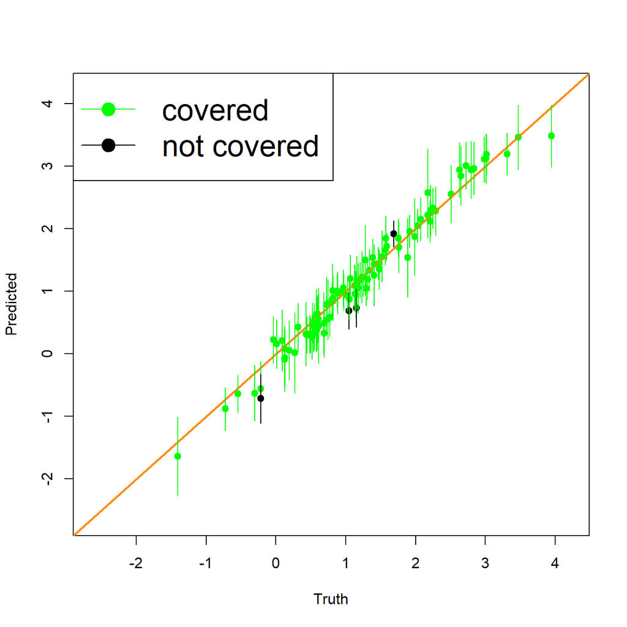

```r
  RLTPred <- predict(RLTfit, testX, var.est = TRUE, keep.all = TRUE)

  # coverage on the testing data
  upper = RLTPred$Prediction + 1.96*sqrt(RLTPred$Variance)
  lower = RLTPred$Prediction - 1.96*sqrt(RLTPred$Variance)
  cover = (1 + testX$X1 > lower) & (1 + testX$X1 < upper)

  plot(1 + testX$X1, RLTPred$Prediction, pch = 19,
       col = ifelse(is.na(cover), "red", ifelse(cover, "green", "black")),
       xlab = "Truth", ylab = "Predicted",
       xlim = c(min(y)+1, max(y)-1), ylim = c(min(y)+1, max(y)-1))

  abline(0, 1, col = "darkorange", lwd = 2)

  for (i in 1:testn)
    segments(1+testX$X1[i], lower[i], 1+testX$X1[i], upper[i],
             col = ifelse(is.na(cover[i]), "red", ifelse(cover[i], "green", "black")))

  legend("topleft", c("covered", "not covered"), col = c("green", "black"),
         lty = 1, pch = 19, ce = 2)
```

## Setting random seed

```r
  ## Fitting a forest
  RLTfit1 <- RLT(trainX, trainY, model = "regression",
                 ntrees = 100, importance = TRUE, nmin = 1)

  RLTfit2 <- RLT(trainX, trainY, model = "regression",
                 ntrees = 100, importance = TRUE, nmin = 1,
                 seed = RLTfit1$parameters$seed)

  # check if importance are identical
  all(RLTfit1$VarImp == RLTfit2$VarImp)
```

```
## [1] TRUE
```

```r
  # prediction
  RLTPred1 <- predict(RLTfit1, testX, keep.all = TRUE)
  RLTPred2 <- predict(RLTfit2, testX, keep.all = TRUE)

  # check predictions are identical
  all(RLTPred1$Prediction == RLTPred2$Prediction)
```

```
## [1] TRUE
```